# Popularity of WeRateDogs Tweets by Dog 'Stage'

WeRateDogs is a popular twitter page which shares images of dogs with clever captions and ratings. WeRateDogs uses an unconventional rating system, with numerators frequently surpassing the denominators. Within several captions, a dog 'stage' is mentioned (doggo, pupper, puppo, or floofer). Some tweets included multiple dog stages. The following charts explore the relationship between the dog stage and the popularity of the tweet(measured by retweets and favorites) to determine which dog stage recieves the most fan interaction on average.

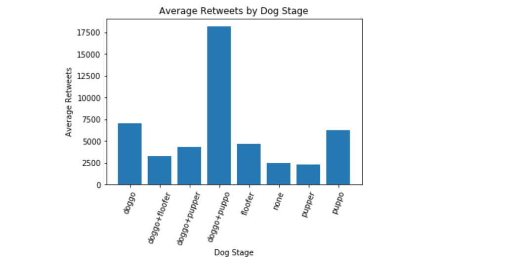

In plotting dog stage against average retweets, the doggo+puppo combination generated the greatest number of retweets, followed by doggo, then puppo. The pupper stage appears the least popular; even the tweets with no stage indicated recieved a higher average number of retweets.

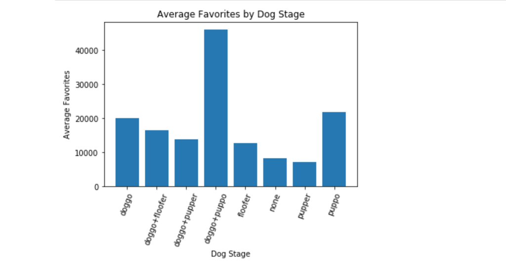

In plotting dog stage against average favorites, the doggo+puppo combination generated the greatest number of favorites, followed by puppo, then doggo. Again, the pupper stage appears the least popular; even the tweets with no stage indicated recieved a higher average number of favorites.

The overall most popular stage from the twitter page was the doggo+puppo combination, recieving the highest average number of both retweets and favorites. I am curious if this is a result of twitter fans enjoying the multiple methods of referencing the dogs.

Following the doggo+puppo combination, the doggo stage and puppo stage were the next most popular stages. The doggo stage had the second greatest number of retweets and third greatest number of favorites. The puppo stage had the second greatest number of favorites and third greatest number of retweets. I find it intereting that the two stages ending in 'o' generated the most activity. Clearly, we 'o' these puppos and doggos a round of applause!